# How Can a Wellness Technology Company Play It Smart?

Chinazom Jennifer Okoli

2023-12-09

## Introduction

Bellabeat is a high-tech company that manufactures health-focused smart products for women. Collecting data on activity, sleep, stress, and reproductive health has allowed Bellabeat to empower women with knowledge about their own health and habits. Bellabeat products comprises of the Bellabeat app, Leaf (which is worn as a bracelet, necklace, or clip), Time (wellness watch) and Spring (water bottle). All the other products are connected to the Bellabeat App.

Urška Sršen, co-founder and Chief Creative Officer of Bellabeat, believes that analyzing smart device fitness data could help unlock new growth opportunities for the company.Sršen asks to analyze smart device usage data in order to gain insight into how consumers use non-Bellabeat smart devices. We’re to focus on Bellabeat’s product, **Time**, and examine data from **fitness tracker**—a smart device similar to Bellabeat’s, made by a different company called **Fitbit**. This analysis aims to understand how consumers are utilizing these smart devices.

The tool we’re using for this study is RMarkdown within RStudo. This will enable us to conduct analysis, create visualizations, document our work, and facilitate seamless sharing of results.

## Buisness Goal

- To find some trends in smart device usage.
- How these trends could apply to Bellabeat customers.
- How these trends could help influence Bellabeat marketing strategy.

## Installing and loading common packages and libraries for our analysis.

First off, we set a CRAN mirror;this specifies the location from which R will download packages when we install them. CRAN (Comprehensive R Archive Network) is a network of servers worldwide that mirror the same collection of R packages. By setting a CRAN mirror, we are telling R where to fetch the packages from.

The code below is a combination of R code and Markdown syntax and is typically used in R Markdown (Rmd) documents.

```r
knitr::opts_chunk$set(echo = TRUE)
# Set a CRAN mirror
options(repos = c(CRAN = "https://cloud.r-project.org"))
```

```r
# Install packages
install.packages("tidyverse")
install.packages("dplyr")
library("tidyverse")
library(dplyr)
library(magrittr)
library(purrr)
```

## Loading and exploring our CSV files

Here we created data frames with the same name as our CSV files from the dataset and import them using the file path; Typed in the data frame name, the assignment operator(<-), then the read.csv() which is the function for importing CSV files in R finally the file path which was gotten by clicking on the data file then **copy as path**. Paste in the parenthesis of the read.csv.

```r
 dailyActivity_merged <- read.csv("C:/Users/ADMIN/OneDrive/Documents/Fitabase Data 4.12.16-5.12.16/dailyActivity_merged.csv")

 View(dailyActivity_merged)

 sleepDay_merged <- read.csv("C:/Users/ADMIN/OneDrive/Documents/Fitabase Data 4.12.16-5.12.16/sleepDay_merged.csv")

 View(sleepDay_merged)
```

We will concentrate on specific CSV files for this analysis among the provided 18, as many share identical data, and a few contain incomplete data which won’t be relevant for this study.

## Understanding some summary statistics

In this analysis, we are consolidating our data by computing the average of each variable. Data is aggregated and averaged in analysis to provide a summary measure that represents the central tendency of a set of values. This simplifies complex datasets, highlights overall trends, and facilitates easier interpretation of the information.

Averaging helps smooth out variations, making it a commonly used method for obtaining a representative value from a larger dataset.

The syntax used in the first analysis was explained below as a guide for the subsequent analysis.

### To create a new data frame ‘calculated_average_activity’ to know the average activity of each participant for this period of time.

```r
calculated_average_activity <- dailyActivity_merged %>%
  group_by(Id) %>%
  summarise(
    AVGVeryActive = mean(as.integer(VeryActiveMinutes), na.rm = TRUE),
    AVGFairlyActive = mean(as.integer(FairlyActiveMinutes), na.rm = TRUE),
    AVGLightActive = mean(as.integer(LightlyActiveMinutes), na.rm = TRUE),
    AVG_Activity = mean(
      as.integer(VeryActiveMinutes) +
      as.integer(FairlyActiveMinutes) +
      as.integer(LightlyActiveMinutes),
      na.rm = TRUE
    )
  )
```

### Let’s break down the syntax and understand each part:

**Calculation of Average Activity:**

- AVGVeryActive: Average value of VeryActiveMinutes for each ID.
- AVGFairlyActive: Average value of FairlyActiveMinutes for each ID.
- AVGLightActive: Average value of LightlyActiveMinutes for each ID.

**Calculation of Total Activity:**

- AVG_Activity: Average total activity, which is the sum of VeryActiveMinutes, FairlyActiveMinutes, and LightlyActiveMinutes for each ID.

**Data Frame Creation:**

- The results are stored in a new data frame named ‘calculated_average_activity’.
- Each row of this data frame corresponds to a unique ID, and the columns represent the calculated average values.

```r
# Print the result
print(calculated_average_activity)
```

```
## # A tibble: 33 × 5
##            Id AVGVeryActive AVGFairlyActive AVGLightActive AVG_Activity
##         <dbl>         <dbl>           <dbl>          <dbl>        <dbl>
##  1 1503960366       38.7             19.2            220.         278.
##  2 1624580081        8.68             5.81           153.         168.
##  3 1644430081        9.57            21.4            178.         209.
##  4 1844505072        0.129            1.29           115.         117.
##  5 1927972279        1.32             0.774           38.6         40.7
##  6 2022484408       36.3             19.4            257.         313.
##  7 2026352035        0.0968           0.258          257.         257
##  8 2320127002        1.35             2.58           198.         202.
##  9 2347167796       13.5             20.6            252.         287.
## 10 2873212765       14.1              6.13           308          328.
## # ℹ 23 more rows
```

**Calculating the AVGSedentaryTime**

```r
averageSedentary_time <- dailyActivity_merged %>%
  group_by(Id) %>%
  summarise(
    AVG_SedentaryMinutes = as.integer(mean(as.integer(SedentaryMinutes), na.rm = TRUE))
  )
```

**Calculating the average of TotalMinutesAsleep and TotalTimeInBed as ‘average_BedTime’**

```r
average_BedTime <- sleepDay_merged %>%
  group_by(Id) %>%
  summarise(
    AVG_TotalMinutesAsleep = as.integer(mean(as.integer(TotalMinutesAsleep), na.rm = TRUE)),
    AVG_TotalTimeInBed = as.integer(mean(as.integer(TotalTimeInBed), na.rm = TRUE))
)
```

### To merge the both data frame as average_Inactivity

```r
average_Inactivity <- inner_join(average_BedTime, averageSedentary_time, by = "Id")
```

```r
# Print the result
print(average_Inactivity)
```

```
## # A tibble: 24 × 4
##            Id AVG_TotalMinutesAsleep AVG_TotalTimeInBed AVG_SedentaryMinutes
##         <dbl>                  <int>              <int>                <int>
##  1 1503960366                    360                383                  848
##  2 1644430081                    294                346                 1161
##  3 1844505072                    652                961                 1206
##  4 1927972279                    417                437                 1317
##  5 2026352035                    506                537                  689
##  6 2320127002                     61                 69                 1220
##  7 2347167796                    446                491                  687
##  8 3977333714                    293                461                  707
##  9 4020332650                    349                379                 1237
## 10 4319703577                    476                501                  735
## # ℹ 14 more rows
```

### To calculate the average TotalSteps and TrackerDistance as ‘averageSteps_Distance’

```r
averageSteps_Distance <- dailyActivity_merged %>%
  group_by(Id) %>%
  summarise(
    AVG_TotalSteps = as.integer(mean(as.integer(TotalSteps), na.rm = TRUE)),
    AVG_TrackerDistance = mean(TrackerDistance, na.rm = TRUE),
  )
```

```r
# Print the result
print(averageSteps_Distance)
```

```
## # A tibble: 33 × 3
##            Id AVG_TotalSteps AVG_TrackerDistance
##         <dbl>          <int>               <dbl>
##  1 1503960366          12116               7.81
##  2 1624580081           5743               3.91
##  3 1644430081           7282               5.30
##  4 1844505072           2580               1.71
##  5 1927972279            916               0.635
##  6 2022484408          11370               8.08
##  7 2026352035           5566               3.45
##  8 2320127002           4716               3.19
##  9 2347167796           9519               6.36
## 10 2873212765           7555               5.10
## # ℹ 23 more rows
```

### To calculate average Calories

```r
average_Calories <- dailyActivity_merged %>%
  group_by(Id) %>%
  summarise(
    AVG_Calories = as.integer(mean(as.integer(Calories), na.rm = TRUE))
  )
```

```r
print(average_Calories)
```

```
## # A tibble: 33 × 2
##            Id AVG_Calories
##         <dbl>        <int>
##  1 1503960366         1816
##  2 1624580081         1483
##  3 1644430081         2811
##  4 1844505072         1573
##  5 1927972279         2172
##  6 2022484408         2509
##  7 2026352035         1540
##  8 2320127002         1724
##  9 2347167796         2043
## 10 2873212765         1916
## # ℹ 23 more rows
```

### To merge all calculated data frames into a data frame ‘FitbaseData_Calculated’ for easy visualization

```r
# List of data frames
df_list <- list(average_BedTime, average_Calories, average_Inactivity, averageSedentary_time, averageSteps_Distance, calculated_average_activity)

# Merge data frames in the list based on the common column (Id)
FitbaseData_Calculated <- reduce(df_list, merge, by = "Id",all = TRUE)

# Resulting data frame (FitbaseData_Calculated)
print(FitbaseData_Calculated)
```

```
##            Id AVG_TotalMinutesAsleep.x AVG_TotalTimeInBed.x AVG_Calories
## 1  1503960366                      360                  383         1816
## 2  1624580081                       NA                   NA         1483
## 3  1644430081                      294                  346         2811
## 4  1844505072                      652                  961         1573
## 5  1927972279                      417                  437         2172
## 6  2022484408                       NA                   NA         2509
## 7  2026352035                      506                  537         1540
## 8  2320127002                       61                   69         1724
## 9  2347167796                      446                  491         2043
## 10 2873212765                       NA                   NA         1916
## 11 3372868164                       NA                   NA         1933
## 12 3977333714                      293                  461         1513
## 13 4020332650                      349                  379         2385
## 14 4057192912                       NA                   NA         1973
```

[output cut: 121 more lines]

## Plotting some explorations using Scatter plot and Smoothing.

The relationship between two variables in a scatter plot provides valuable insights into overall activity levels. A negative correlation suggests that as one variable increases, the other decreases, indicating a potential link between them. Conversely, a positive correlation implies that higher values in one variable are associated with higher values in the other. A zero correlation suggests the absence of a linear relationship between two variables. It indicates that changes in one variable are not systematically associated with changes in the other, meaning that as values of one variable vary, there is no consistent pattern or trend in the values of the other variable.

Adding Smoothing to a scatter plot enhances the interpretability of the plot, making it easier to identify general patterns and draw insights.

Understanding this correlation helps tailor health recommendations and customize product messaging and features to address the specific needs of different customer segments, enhancing overall user engagement and satisfaction.

Let’s find trends using visualization, we first load our plotting package - ggplot2

```r
library("ggplot2")
```

**How are the number of steps taken related to the duration of sedentary minutes?**

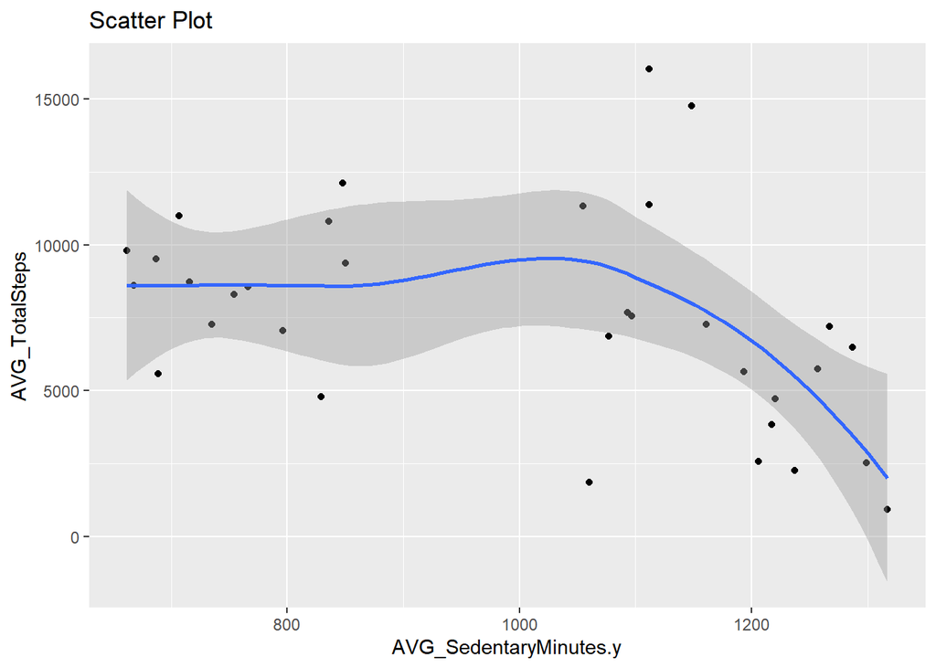

```r
# Creating scatter plot
ggplot(data=FitbaseData_Calculated, aes(x=AVG_SedentaryMinutes.y, y=AVG_TotalSteps))+
geom_point() +
labs(title = "Scatter Plot", x = "AVG_SedentaryMinutes.y", y = "AVG_TotalSteps")+
  geom_smooth()
```

The trend in this scatter plot shows that as **Average Total Steps** increases, **average Sedentary Minutes** decreases. This suggests that there is a **negative relationship** between Average Total Steps and average Sedentary Minutes. In other words, the more steps a person takes, the less time they spend sitting. This could imply that physical activity is inversely related to sedentary behavior.

**A summarized explanation of the above syntax which will guide as a reference for subsequent ones.**

The syntax employs functions from the “ggplot2” package in R. The ggplot() function initializes the plot, aes() specifies the aesthetic mappings that is which variable takes either the x or y axis. The geom_point() for scattered plot, adds points to the plot, labs() sets the title and axis labels, and geom_smooth() incorporates a smoothed trend line. Additionally, drop_na() is used for handling missing values in the data.

**Relationship between activity and sleep**

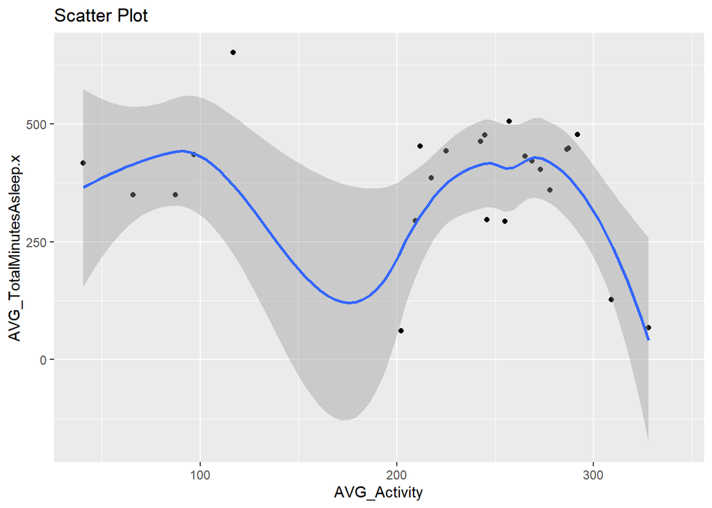

```r
ggplot(data=FitbaseData_Calculated, aes(x=AVG_Activity, y=AVG_TotalMinutesAsleep.x,drop_na()))+
  geom_point() +
  labs(title = "Scatter Plot", x = "AVG_Activity", y = "AVG_TotalMinutesAsleep.x")+
  geom_smooth()
```

However, this graph does not imply causation, only correlation. There could be other factors that affect both variables, such as age, health, or environment.

**To check relationship between Tracker Distance and Total Steps**

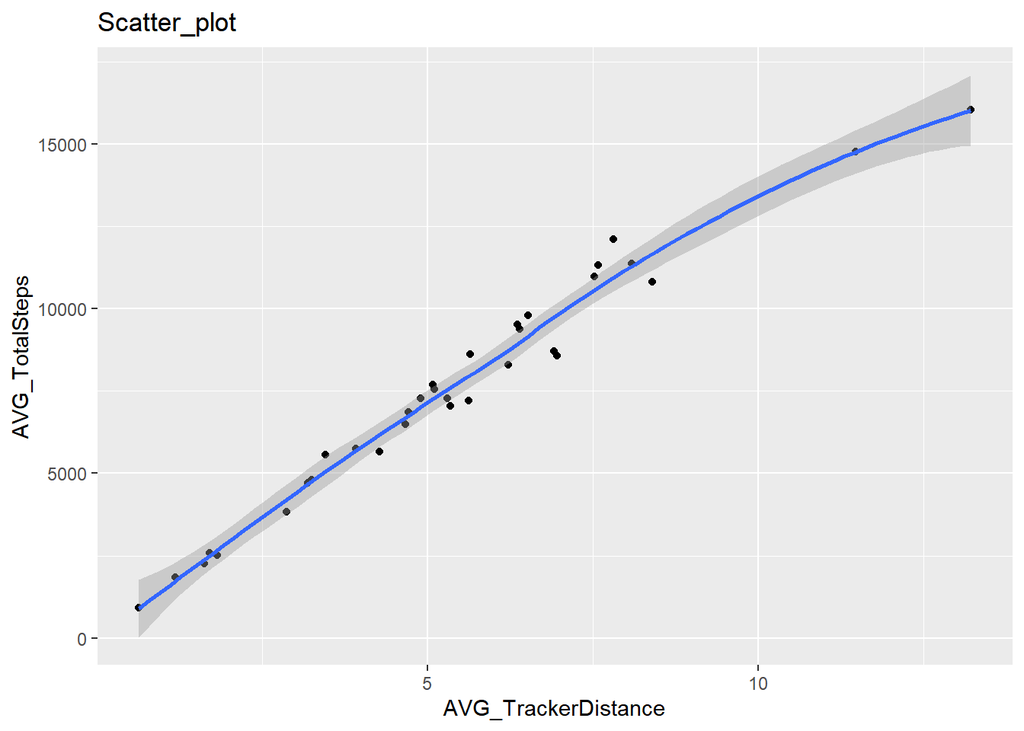

```r
ggplot(data=FitbaseData_Calculated, aes(x=AVG_TrackerDistance, y=AVG_TotalSteps,))+
  geom_point() +
  labs(title = "Scatter_plot", x = "AVG_TrackerDistance", y = "AVG_TotalSteps")+
  geom_smooth()
```

The trend in this scatter plot shows that as the **average tracker distance** increases, the **average total steps** also increases. This suggests that there is a **positive relationship** between the two variables. In other words, the more distance a person covers with their tracker, the more steps they are likely to take. This could imply that people who use trackers are more motivated to walk or exercise more.

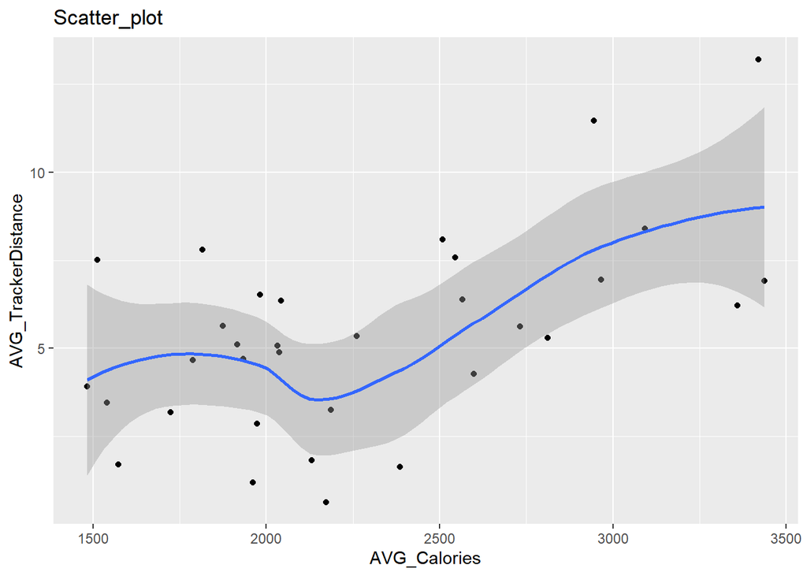

```r
ggplot(data=FitbaseData_Calculated, aes(x=AVG_Calories, y=AVG_TrackerDistance,))+
  geom_point() +
  labs(title = "Scatter_plot", x = "AVG_Calories", y = "AVG_TrackerDistance")+
  geom_smooth()
```

## Conclusion

In summary, these insights will enable Bellabeat to customize communication with users, improve product features, and offer recommendations thereby enhancing user engagement and satisfaction. By promoting an active lifestyle, addressing sleep patterns, emphasizing tracker usage, and highlighting accurate fitness metric measurements, Bellabeat can effectively support its customers’ holistic approach to health and well-being.

## Recommendation

By incorporating these recommendations, Bellabeat can align its marketing strategy and product features with the observed trends, enhancing user engagement and satisfaction among its customers.This will position Bellabeat as a brand that not only provides fitness tracking but also actively supports users in adopting a healthier and more balanced lifestyle. Tailoring messages to resonate with these trends can enhance user engagement and attract a wider audience seeking holistic health solutions.

**While these trends offer valuable insights, it’s crucial to acknowledge that correlation does not imply causation. Bellabeat may consider further research to understand the nuanced factors influencing these trends and refine its offerings accordingly.**